# Sharpchin Rockfish

*Sebastes zacentrus*

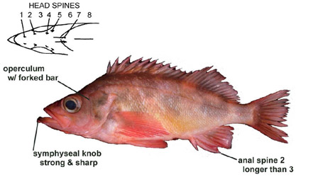

**Body color:** Light red w/ several vague, dark brown blotches on back w/ at least one blotch extending below lateral line.

**Peritoneum color:** dark **Shape between eyes:** convex to concave

**Counts:** D:XIII,13-15, Ar:7-8, P1:16-18, GR:31-41, LLp:39-47, LLs:43-59,V:27

**Occurence:** Aleutian Islands - Southern California

**Depth:** 25-444 meters **Size:** 39 cm **Species code:** 30560

**Similar species:**

- *Harlequin rockfish* - symphyseal knob moderate; dorsal fin black; posterior 2/3 of lateral line clear
- *Darkblotched rockfish* - symphyseal knob weak; head spine count differs; anal spine 2 shorter than 3
- *Halfbanded rockfish* - body dusky pink w/ 2 prominent blotches over lateral line; head spines weak; symphyseal knob weak
- *Pacific Ocean Perch* - head spines weak and typically differ in count; dorsal blotches do not extend below lateral line; blotch on operculum; operculum edge w/ spines
- *Yellowmouth rockfish* - symphyseal knob weaker; yellow blotches inside mouth; dorsal blotches diffuse, do not extend below lateral line; operculum edge w/ spines; blotch on operculum

Back to Group

**Corrections:** If you see mistakes or want to suggest changes, please create an [issue](https://github.com/zoyafuso-NOAA/RACE_Survey_App/issues) on the source repository or

*reach out to Liz Dawson (Liz.Dawson AT noaa.gov).*